# Plotting with ggplot2 - lecture code basics

# FACETS

To avoid the mess we build a different plot for each landuse. **facet_wrap()** does this, it takes as first argument a categorical variable in your dataset (place *~* before the name) and splits the plot into “facets”

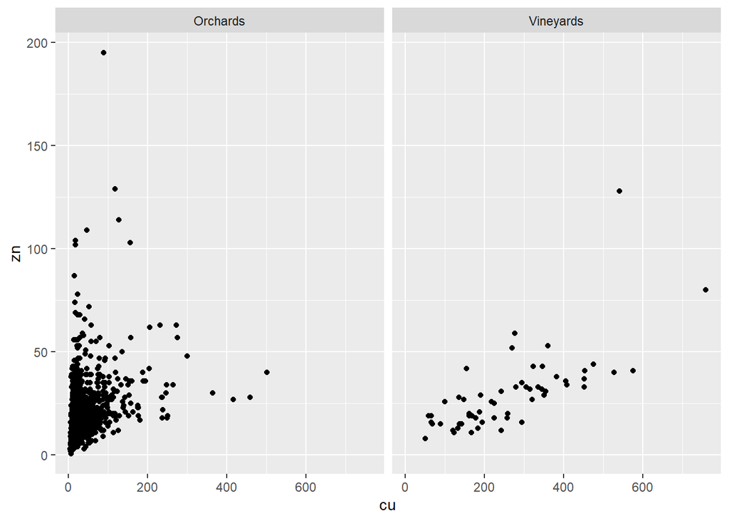

```r
p<- p +
  facet_wrap(~landuse)
p
```

# Theme

We add a classic theme. The **theme_** functions are a series of shortcuts functions to customize the appearence of your plot

[figure not shown]

```r
p<-p + theme_classic(base_size = 50)
p
```

```r
#p + theme_dark()
```

# Color mapping

To wrap it up and show the mapping of color we also place the legend at the bottom with the funciton **theme()** and add title with **ggtitle()** and axis lables with **labs()**

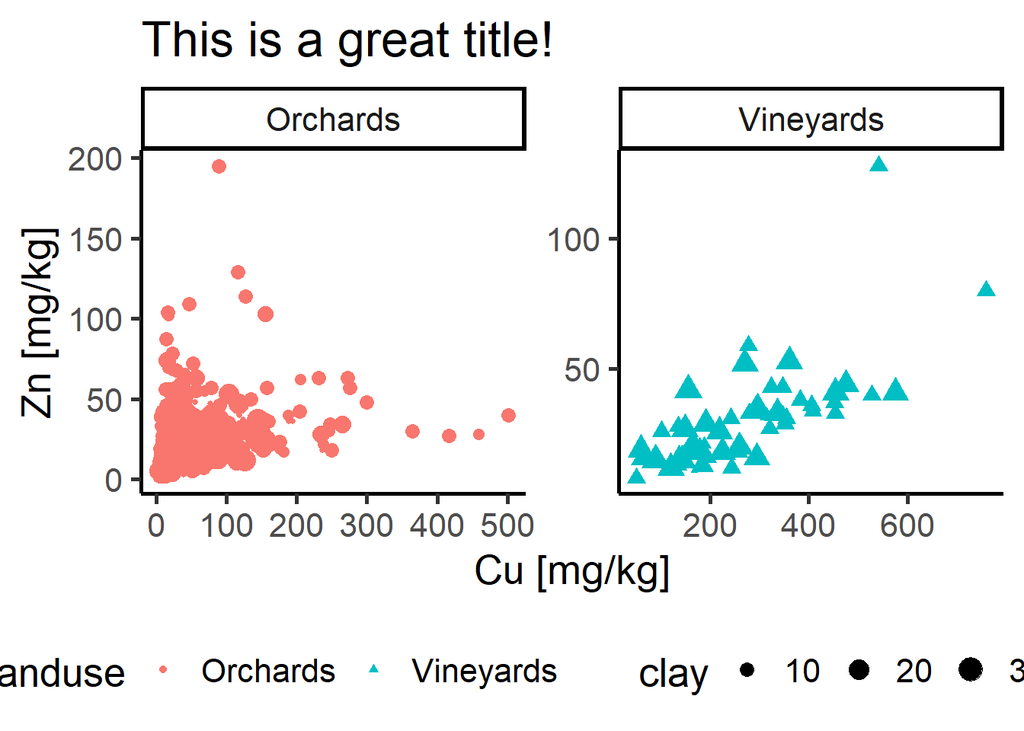

```r
ggplot(df)+
  geom_point(aes(x = cu,y = zn,color = landuse, shape = landuse,size = clay))+
  facet_wrap(~landuse,scales = "free")+
  ggtitle("This is a great title!")+
  labs(x = "Cu [mg/kg]",y = "Zn [mg/kg]")+
  theme_classic(base_size = 20)+
  theme(legend.position = "bottom")
```

Change the color with **scale_color_manual()**. In the function you can specify a vector of colors “manually”. Here a list of available colors in R http://www.stat.columbia.edu/~tzheng/files/Rcolor.pdf.

But you can also specify hexadecimals like this #1fab9e and #c6464a . To find beautiful palettes I usually go here: https://coolors.co/palettes

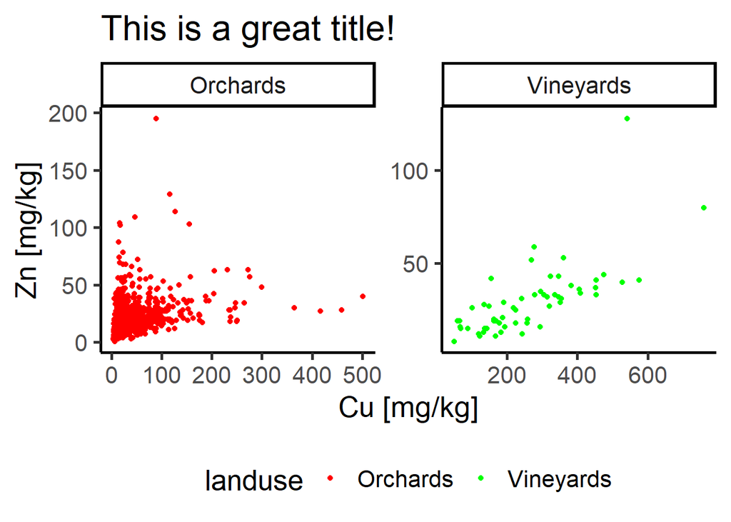

```r
ggplot(df)+
  geom_point(aes(cu,zn,color=landuse))+
  facet_wrap(~landuse,scales = "free")+
  scale_color_manual(values = c("red","green"))+
  ggtitle("This is a great title!")+
  labs(x = "Cu [mg/kg]",y = "Zn [mg/kg]")+
  theme_classic(base_size = 20)+
  theme(legend.position = "bottom")
```

Coords **coord_cartesian()** allows you to zoom in the plot by specifying the limits for which to plot the axis

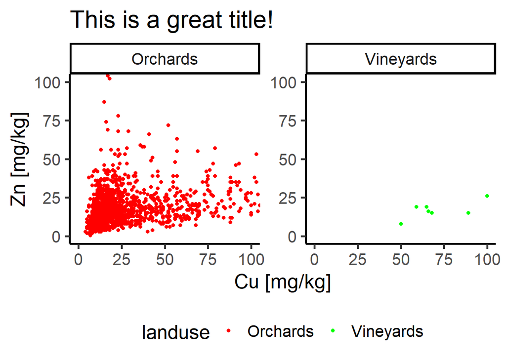

```r
ggplot(df)+
  geom_point(aes(cu,zn,color=landuse))+
  facet_wrap(~landuse,scales = "free")+
  scale_color_manual(values = c("red","green"))+
  coord_cartesian(xlim = c(0,100),ylim = c(0,100))+
  ggtitle("This is a great title!")+
  labs(x = "Cu [mg/kg]",y = "Zn [mg/kg]")+
  theme_classic(base_size = 20)+
  theme(legend.position = "bottom")
```